# Zaawansowana Eksploracja Danych - projekt

Tomasz Nowak

22 sty, 2017

```r
knitr::opts_chunk$set(cache = TRUE)
data <- read.csv(text=getURL("https://raw.githubusercontent.com/NowakTom/ZED/master/sledzie.csv"), na.strings = "?")
```

# 1 Analiza problemu

Analiza zbioru wykazała, iż większość paramterów nie posiada rozkładu normalnego. W ramach korelacji można znaleźć silne powiązania pomiędzy zmiennymi (jak np.: powiązanie pomiędzy gatunkami planktonu).

Bezpośrednio został zidentyfikowany wpływ temperatury wody na długość odławianych śledzi. W ramach spadku temperatury rośnie długość śledzia - czyt. jeżeli jest niższa temperatura wody, wyławiane ryby są dłuższe niż, gdy temperatura wody jest wyższa. Wpływ na temperaturę wody posiada miesiąc połowu. Na jednym z ostatnich histogramów widać, iż śledzie wyławiane są w ostatnich latach w okolicy środka lipca. W przypadku połowu ryb w okolicach czerwca, temperatura wody jest niższa, a co za tym idzie widać zwiększony rozmiar ryb. Na temperaturę wody wpływ również może mieć Oscylacja Północnoatlantycka, która jest związana z globalną cyrkulacją powietrza i wody oceanicznej. Ujawnia się poprzez przypadkowe wahania takich parametrów, jak ciśnienie, temperatura, prędkość wiatru, ilość opadów

Dane zawierały informacje z okresu 60 lat, w przeciągu którego dynamicznie może zmieniać się klimat, za pośrednictwem, którego wpływa się na temperaturę wody przy powierzchni wody.

# 2 Opis danych

Na przestrzeni ostatnich lat zauważono stopniowy spadek rozmiaru śledzia oceanicznego wyławianego w Europie. Do analizy zebrano pomiary śledzi i warunków w jakich żyją z ostatnich 60 lat. Dane były pobierane z połowów komercyjnych jednostek. W ramach połowu jednej jednostki losowo wybierano od 50 do 100 sztuk trzyletnich śledzi.

| Nazwa zmiennej | Opis |
| --- | --- |
| length | długość złowionego śledzia [cm] |
| cfin1 | dostępność planktonu [zagęszczenie Calanus finmarchicus gat. 1] |
| cfin2 | dostępność planktonu [zagęszczenie Calanus finmarchicus gat. 2] |
| chel1 | dostępność planktonu [zagęszczenie Calanus helgolandicus gat. 1] |
| chel2 | dostępność planktonu [zagęszczenie Calanus helgolandicus gat. 2] |
| lcop1 | dostępność planktonu [zagęszczenie widłonogów gat. 1] |
| lcop2 | dostępność planktonu [zagęszczenie widłonogów gat. 2] |
| fbar | natężenie połowów w regionie [ułamek pozostawionego narybku] |
| recr | roczny narybek [liczba śledzi] |
| cumf | łączne roczne natężenie połowów w regionie [ułamek pozostawionego narybku] |
| totaln | łączna liczba ryb złowionych w ramach połowu [liczba śledzi] |
| sst | temperatura przy powierzchni wody [°C] |
| sal | poziom zasolenia wody [Knudsen ppt] |
| xmonth | miesiąc połowu [numer miesiąca] |
| nao | oscylacja północnoatlantycka [mb] |

Wiersze w zbiorze są uporządkowane chronologicznie.

# 3 Rozmiar zbioru i podstawowe statystyki

W zbiorze znajduje się 52582 obserwacji rozmieszczonych w 16 kolumnach (kolumna X posiada informacje na temat liczby porządkowej, zostanie użyta później jako chronologiczny punkt odniesienia przy chociażby określeniu zmiany rozmiaru śledzi w czasie).

Wartości puste znajdują się przede wszystkim w kolumnach odpowiedzialnych za informacje odnośnie dostępności planktonu oraz temperatury przy powierzchni wody.

W tabeli znajdują się również informacje odnośnie wartości minimalnych, maksymalnych, średnich oraz medianach dla poszczególnych zmiennych.

```r
knitr::kable(str(data))
```

```
## 'data.frame':    52582 obs. of  16 variables:
##  $ X     : int  0 1 2 3 4 5 6 7 8 9 ...
##  $ length: num  23 22.5 25 25.5 24 22 24 23.5 22.5 22.5 ...
##  $ cfin1 : num  0.0278 0.0278 0.0278 0.0278 0.0278 ...
##  $ cfin2 : num  0.278 0.278 0.278 0.278 0.278 ...
##  $ chel1 : num  2.47 2.47 2.47 2.47 2.47 ...
##  $ chel2 : num  NA 21.4 21.4 21.4 21.4 ...
##  $ lcop1 : num  2.55 2.55 2.55 2.55 2.55 ...
##  $ lcop2 : num  26.4 26.4 26.4 26.4 26.4 ...
##  $ fbar  : num  0.356 0.356 0.356 0.356 0.356 0.356 0.356 0.356 0.356 0.356 ...
##  $ recr  : int  482831 482831 482831 482831 482831 482831 482831 482831 482831 482831 ...
##  $ cumf  : num  0.306 0.306 0.306 0.306 0.306 ...
##  $ totaln: num  267381 267381 267381 267381 267381 ...
##  $ sst   : num  14.3 14.3 14.3 14.3 14.3 ...
##  $ sal   : num  35.5 35.5 35.5 35.5 35.5 ...
##  $ xmonth: int  7 7 7 7 7 7 7 7 7 7 ...
##  $ nao   : num  2.8 2.8 2.8 2.8 2.8 2.8 2.8 2.8 2.8 2.8 ...
```

```r
knitr::kable(summary(data))
```

|  | X | length | cfin1 | cfin2 | chel1 | chel2 | lcop1 | lcop2 | fbar | recr | cumf | totaln | sst | sal | xmonth | nao |
| --- | --- | --- | --- | --- | --- | --- | --- | --- | --- | --- | --- | --- | --- | --- | --- | --- |
|  | Min. : 0 | Min. :19.0 | Min. : 0.0000 | Min. : 0.0000 | Min. : 0.000 | Min. : 5.238 | Min. : 0.3074 | Min. : 7.849 | Min. :0.0680 | Min. : 140515 | Min. :0.06833 | Min. : 144137 | Min. :12.77 | Min. :35.40 | Min. : 1.000 | Min. :-4.89000 |
|  | 1st Qu.:13145 | 1st Qu.:24.0 | 1st Qu.: 0.0000 | 1st Qu.: 0.2778 | 1st Qu.: 2.469 | 1st Qu.:13.427 | 1st Qu.: 2.5479 | 1st Qu.:17.808 | 1st Qu.:0.2270 | 1st Qu.: 360061 | 1st Qu.:0.14809 | 1st Qu.: 306068 | 1st Qu.:13.60 | 1st Qu.:35.51 | 1st Qu.: 5.000 | 1st Qu.:-1.89000 |
|  | Median :26291 | Median :25.5 | Median : 0.1111 | Median : 0.7012 | Median : 5.750 | Median :21.673 | Median : 7.0000 | Median :24.859 | Median :0.3320 | Median : 421391 | Median :0.23191 | Median : 539558 | Median :13.86 | Median :35.51 | Median : 8.000 | Median : 0.20000 |
|  | Mean :26291 | Mean :25.3 | Mean : 0.4458 | Mean : 2.0248 | Mean :10.006 | Mean :21.221 | Mean : 12.8108 | Mean :28.419 | Mean :0.3304 | Mean : 520367 | Mean :0.22981 | Mean : 514973 | Mean :13.87 | Mean :35.51 | Mean : 7.258 | Mean :-0.09236 |
|  | 3rd Qu.:39436 | 3rd Qu.:26.5 | 3rd Qu.: 0.3333 | 3rd Qu.: 1.7936 | 3rd Qu.:11.500 | 3rd Qu.:27.193 | 3rd Qu.: 21.2315 | 3rd Qu.:37.232 | 3rd Qu.:0.4560 | 3rd Qu.: 724151 | 3rd Qu.:0.29803 | 3rd Qu.: 730351 | 3rd Qu.:14.16 | 3rd Qu.:35.52 | 3rd Qu.: 9.000 | 3rd Qu.: 1.63000 |
|  | Max. :52581 | Max. :32.5 | Max. :37.6667 | Max. :19.3958 | Max. :75.000 | Max. :57.706 | Max. :115.5833 | Max. :68.736 | Max. :0.8490 | Max. :1565890 | Max. :0.39801 | Max. :1015595 | Max. :14.73 | Max. :35.61 | Max. :12.000 | Max. : 5.08000 |
|  | NA | NA | NA’s :1581 | NA’s :1536 | NA’s :1555 | NA’s :1556 | NA’s :1653 | NA’s :1591 | NA | NA | NA | NA | NA’s :1584 | NA | NA | NA |

# 4 Brakujące dane

Brakujące dane w zbiorze podczas zaczytywania pliku zostały zamienione z znaków “?” na “NA”. Z racji złożoności zbioru wiersze nie zawierające informacji zostały usunięte, parametry w zbiorze po oczyszczeniu przedstawiały się następująco.

```r
apply(data, 2, function(x) sum(is.na(x)))
```

```
##      X length  cfin1  cfin2  chel1  chel2  lcop1  lcop2   fbar   recr
##      0      0   1581   1536   1555   1556   1653   1591      0      0
##   cumf totaln    sst    sal xmonth    nao
##      0      0   1584      0      0      0
```

```r
data <- na.omit(data)
knitr::kable(summary(data))
```

|  | X | length | cfin1 | cfin2 | chel1 | chel2 | lcop1 | lcop2 | fbar | recr | cumf | totaln | sst | sal | xmonth | nao |
| --- | --- | --- | --- | --- | --- | --- | --- | --- | --- | --- | --- | --- | --- | --- | --- | --- |
|  | Min. : 1 | Min. :19.0 | Min. : 0.0000 | Min. : 0.0000 | Min. : 0.000 | Min. : 5.238 | Min. : 0.3074 | Min. : 7.849 | Min. :0.0680 | Min. : 140515 | Min. :0.06833 | Min. : 144137 | Min. :12.77 | Min. :35.40 | Min. : 1.000 | Min. :-4.89000 |
|  | 1st Qu.:13233 | 1st Qu.:24.0 | 1st Qu.: 0.0000 | 1st Qu.: 0.2778 | 1st Qu.: 2.469 | 1st Qu.:13.427 | 1st Qu.: 2.5479 | 1st Qu.:17.808 | 1st Qu.:0.2270 | 1st Qu.: 360061 | 1st Qu.:0.14809 | 1st Qu.: 306068 | 1st Qu.:13.60 | 1st Qu.:35.51 | 1st Qu.: 5.000 | 1st Qu.:-1.90000 |
|  | Median :26308 | Median :25.5 | Median : 0.1111 | Median : 0.7012 | Median : 5.750 | Median :21.435 | Median : 7.0000 | Median :24.859 | Median :0.3320 | Median : 421391 | Median :0.23191 | Median : 539558 | Median :13.86 | Median :35.51 | Median : 8.000 | Median : 0.20000 |
|  | Mean :26316 | Mean :25.3 | Mean : 0.4457 | Mean : 2.0269 | Mean :10.016 | Mean :21.197 | Mean : 12.8386 | Mean :28.396 | Mean :0.3306 | Mean : 519877 | Mean :0.22987 | Mean : 515082 | Mean :13.87 | Mean :35.51 | Mean : 7.252 | Mean :-0.09642 |
|  | 3rd Qu.:39447 | 3rd Qu.:26.5 | 3rd Qu.: 0.3333 | 3rd Qu.: 1.7936 | 3rd Qu.:11.500 | 3rd Qu.:27.193 | 3rd Qu.: 21.2315 | 3rd Qu.:37.232 | 3rd Qu.:0.4650 | 3rd Qu.: 724151 | 3rd Qu.:0.29803 | 3rd Qu.: 730351 | 3rd Qu.:14.16 | 3rd Qu.:35.52 | 3rd Qu.: 9.000 | 3rd Qu.: 1.63000 |
|  | Max. :52580 | Max. :32.5 | Max. :37.6667 | Max. :19.3958 | Max. :75.000 | Max. :57.706 | Max. :115.5833 | Max. :68.736 | Max. :0.8490 | Max. :1565890 | Max. :0.39801 | Max. :1015595 | Max. :14.73 | Max. :35.61 | Max. :12.000 | Max. : 5.08000 |

# 5 Szczegółowa analiza wartości atrybutów

Zbiór, który w ramach analizy jest przetwarzany, posiada duże ilości rekordów. Zastosowanie tutaj zwykłych wykresów liniowych czy punktowych wyświetla dość spiętrzone wyniki, które są bardzo trudne w analizie. Aby zastosować te metody analizy graficznej atrybutów należałoby odpowiednio dane próbkować. Istnieje również inne możliwe przedstawienie informacji o danych, zastosowanie wykresów gęstości, bądź histogramów, które są w stanie określić liczebność zmiennych w poszczególnych przedziałach. W ramach prezentacji atrybutów tymczasowo w zbiorze pominięty został atrybut oznaczający liczbę porządkową.

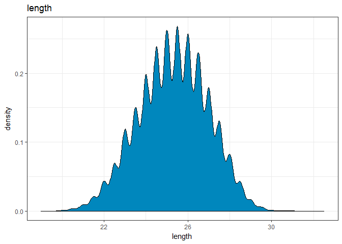

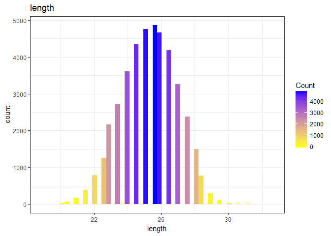

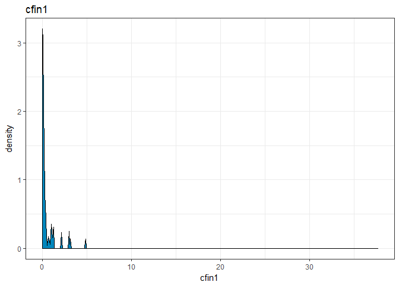

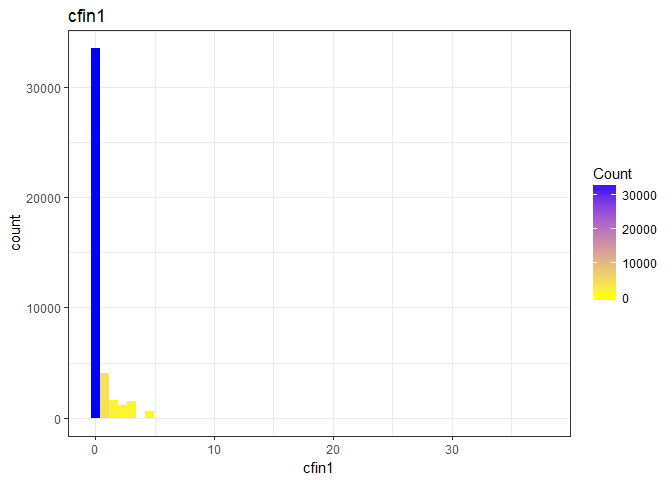

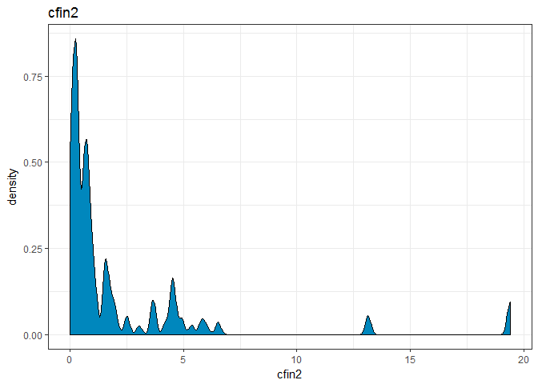

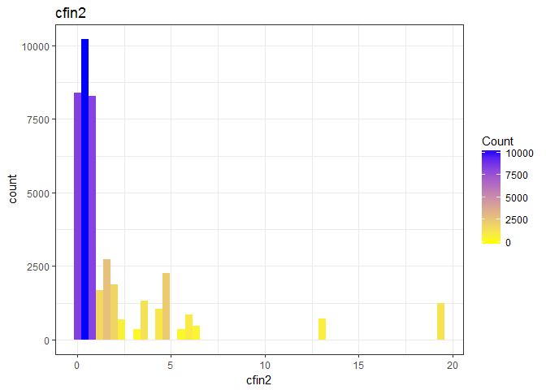

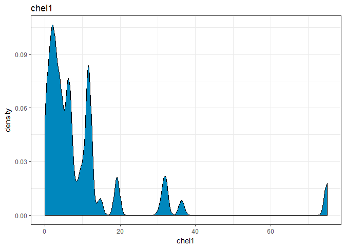

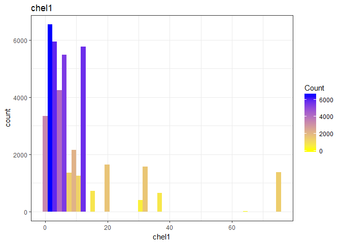

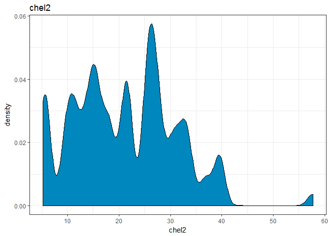

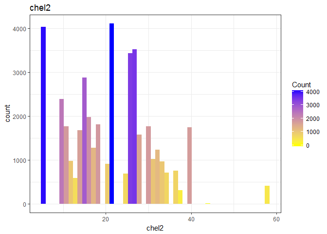

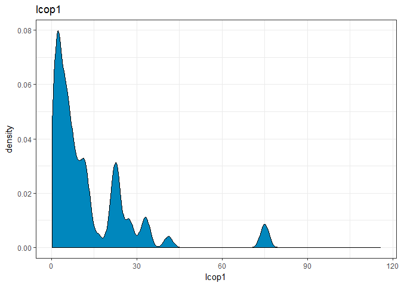

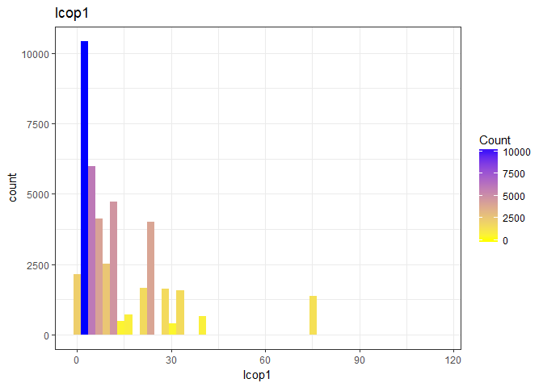

[18 more figures not shown]

```r
data_geom <- select(data,-X)
for (i in colnames(data_geom)) {print(ggplot(data_geom,aes_string(x = i)) + geom_density(fill = "#0087BD") + ggtitle(i) + theme_bw())
print(ggplot(data_geom,aes_string(x = i)) + geom_histogram(bins = 50,aes(fill = ..count..)) + scale_fill_gradient("Count", low = "yellow", high = "blue") + ggtitle(i) + theme_bw()) }
```

# 6 Wykres prezentujący zmianę rozmiaru śledzi w czasie

Interaktywny wykres, w którym udział biorą dwie zmienne, liczba porządkowa = X oraz długość śledzia = length. Z racji tego, iż zbiór ustawiony jest chronologicznie, liczba porządkowa jest puntkem odniesienia w czasie.

```r
sledzie_w_czasie<-ggplot(data,aes(X,length)) + geom_smooth() + theme_bw() + ggtitle("Zmiana rozmiaru śledzi w czasie") + labs(x= "Czas",y="Rozmiar śledzi")
ggplotly(sledzie_w_czasie)
```

[interactive chart not shown]

# 7 Korelacja między zmiennymi

Z powyższych wykresów gęstości poszczególnych zmiennych można wyciągnąć wnioski, iż dane w zbiorze (poza zmienną length) nie posiadają normalnego rozkładu. Dodatkowo niektóre dane są bardziej odległe od innych w ramach pojedyńczego zbioru. Wobec powyższych wniosków korelacja została wykonana metodą Spearman’a.

```r
korelacja <- cor(data, method = "spearman")
heatmaply(korelacja, k_col = 2, k_row = 3) %>% layout(margin = list(l = 130, b = 40))
```

[interactive chart not shown]

# 8 Regresor przewidujący rozmiar śledzia

```r
fit_lm<-select(data,-X)
fit_lm <- lm(length ~ ., fit_lm)
summary(fit_lm)
```

```
##
## Call:
## lm(formula = length ~ ., data = fit_lm)
##
## Residuals:
##     Min      1Q  Median      3Q     Max
## -7.6008 -0.9324  0.0000  0.9135  6.9460
##
## Coefficients:
##               Estimate Std. Error t value Pr(>|t|)
## (Intercept)  6.011e+01  7.057e+00   8.518  < 2e-16 ***
## cfin1        1.305e-01  7.593e-03  17.181  < 2e-16 ***
## cfin2        1.518e-02  4.367e-03   3.477 0.000508 ***
## chel1       -1.130e-02  1.880e-03  -6.009 1.88e-09 ***
## chel2       -5.552e-03  2.763e-03  -2.010 0.044466 *
## lcop1        2.262e-02  1.752e-03  12.914  < 2e-16 ***
## lcop2        1.240e-02  2.297e-03   5.400 6.68e-08 ***
## fbar         6.136e+00  9.463e-02  64.840  < 2e-16 ***
## recr        -4.055e-07  3.107e-08 -13.054  < 2e-16 ***
## cumf        -1.019e+01  1.765e-01 -57.749  < 2e-16 ***
## totaln      -5.776e-07  5.937e-08  -9.729  < 2e-16 ***
## sst         -1.260e+00  2.239e-02 -56.294  < 2e-16 ***
## sal         -4.808e-01  1.998e-01  -2.406 0.016131 *
## xmonth       1.081e-02  2.404e-03   4.499 6.84e-06 ***
## nao          3.527e-02  4.672e-03   7.549 4.49e-14 ***
## ---
## Signif. codes:  0 '***' 0.001 '**' 0.01 '*' 0.05 '.' 0.1 ' ' 1
##
## Residual standard error: 1.36 on 42473 degrees of freedom
## Multiple R-squared:  0.3207, Adjusted R-squared:  0.3204
## F-statistic:  1432 on 14 and 42473 DF,  p-value: < 2.2e-16
```

```r
summary(fit_lm)$r.squared
```

```
## [1] 0.3206648
```

```r
RMSE <- function(num) sqrt(sum(num^2)/length(num))
RMSE(fit_lm$residuals)
```

```
## [1] 1.359618
```

```r
inTraining <-
    createDataPartition(
        y = data$length,
        p = .75,
        list = FALSE)

training <- data[ inTraining,]
testing  <- data[-inTraining,]

ctrl <- trainControl(
    method = "repeatedcv",
    number = 2,
    repeats = 5)
set.seed(23)
fit <- train(length ~ .,
             data = training,
             method = "rf",
             trControl = ctrl,
             ntree = 2)
fit
```

```
## Random Forest
##
## 31868 samples
##    15 predictor
##
## No pre-processing
## Resampling: Cross-Validated (2 fold, repeated 5 times)
## Summary of sample sizes: 15935, 15933, 15934, 15934, 15933, 15935, ...
## Resampling results across tuning parameters:
##
##   mtry  RMSE      Rsquared
##    2    1.162072  0.5051913
##    8    1.165133  0.5110281
##   15    1.284890  0.4518674
##
## RMSE was used to select the optimal model using  the smallest value.
## The final value used for the model was mtry = 2.
```

```r
rfClasses <- predict(fit, newdata = testing)
summary(rfClasses)
```

```
##    Min. 1st Qu.  Median    Mean 3rd Qu.    Max.
##   22.53   24.75   25.33   25.31   26.17   28.17
```

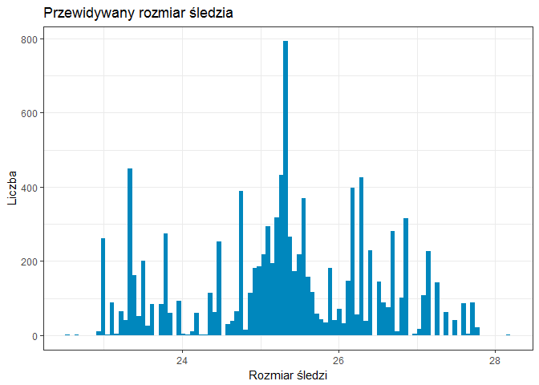

```r
df<-data.frame(rfClasses)
ggplot(df,aes_string(x = rfClasses)) + geom_histogram(bins=100, fill = "#0087BD")  + ggtitle("Przewidywany rozmiar śledzia") + theme_bw() + labs(x= "Rozmiar śledzi",y="Liczba")
```

# 9 Analiza ważności atrybutów

```r
fit_RF<-select(data,-X)
fit_RF <- randomForest(length ~ ., fit_RF)
print(fit_RF)
```

```
##
## Call:
##  randomForest(formula = length ~ ., data = fit_RF)
##                Type of random forest: regression
##                      Number of trees: 500
## No. of variables tried at each split: 4
##
##           Mean of squared residuals: 1.343042
##                     % Var explained: 50.64
```

```r
fit_RF
```

```
##
## Call:
##  randomForest(formula = length ~ ., data = fit_RF)
##                Type of random forest: regression
##                      Number of trees: 500
## No. of variables tried at each split: 4
##
##           Mean of squared residuals: 1.343042
##                     % Var explained: 50.64
```

```r
fit_importance <- importance(fit_RF)
fit_importance <- data.frame(zmienna = rownames(fit_importance), waznosc = fit_importance[, 1])
fit_importance$zmienna <- factor(fit_importance$zmienna, levels = fit_importance[order(fit_importance$waznosc), "zmienna"])
set.seed(42)
```

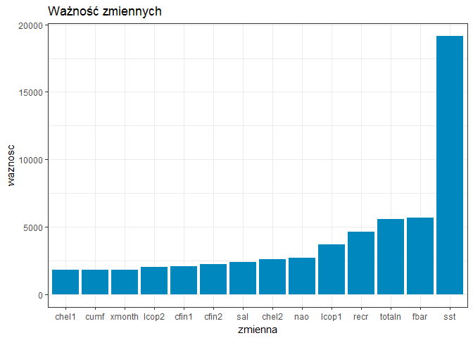

```r
ggplot(fit_importance, aes(x = zmienna, y = waznosc)) + geom_bar(stat = "identity", fill = "#0087BD") + ggtitle("Ważność zmiennych") + theme_bw()
```

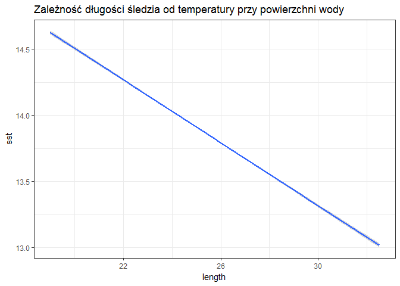

```r
ggplot(data, aes(x = length, y = sst)) + geom_smooth(method = "lm") + ggtitle("Zależność długości śledzia od temperatury przy powierzchni wody") + theme_bw()
```

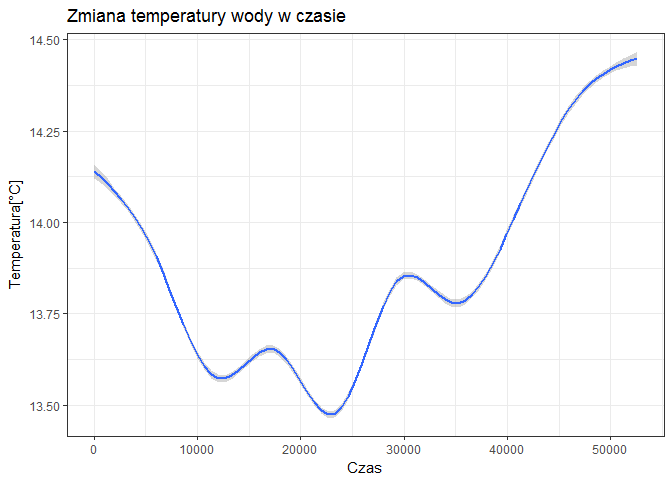

```r
ggplot(data,aes(X,sst)) + geom_smooth() + theme_bw() + ggtitle("Zmiana temperatury wody w czasie") + labs(x= "Czas",y="Temperatura[°C]")
```

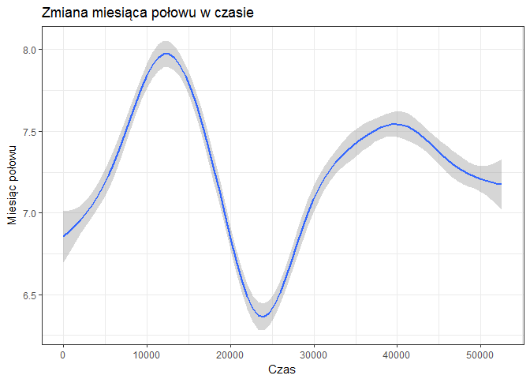

```r
ggplot(data,aes(X,xmonth)) + geom_smooth() + theme_bw() + ggtitle("Zmiana miesiąca połowu w czasie") + labs(x= "Czas",y="Miesiąc połowu")
```

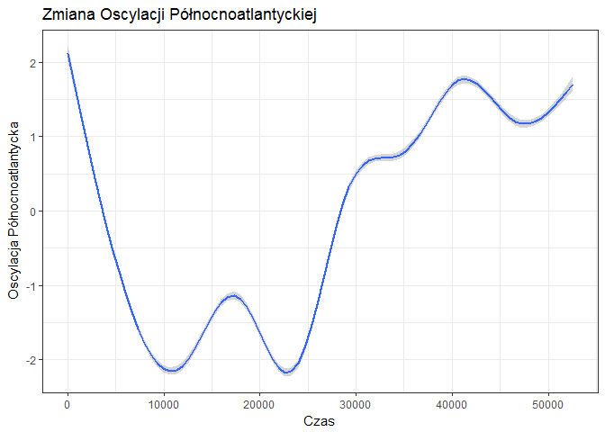

```r
ggplot(data,aes(X,nao)) + geom_smooth() + theme_bw() + ggtitle("Zmiana Oscylacji Północnoatlantyckiej") + labs(x= "Czas",y="Oscylacja Północnoatlantycka")
```